# screp

xum

2023-08-06

## 加载R包以及设置工作目录

```r
setwd("~/Suolab/TCR/scTCR/")

library(scRepertoire)
```

```r
library(stringr)
library(ggplot2)
library(patchwork)
library(ggsci)
library(RColorBrewer)
```

## 文件读入

设计程序读取cellranger 注释的TCR结果文件

```r
# 获取当前工作目录
workdir <- "~/Suolab/TCR/scTCR/"

# 列出workdir下的所有文件/目录
#all_items <- list.files(workdir)

# 保留只有目录的部分
#dirs <- all_items[file.info(file.path(workdir, all_items))$isdir]

# 定义sample变量
samples <- list.files(workdir)

contig_list <- vector("list", length(samples))

for(i in seq_along(samples)){

  file <- paste0("~/Suolab/TCR/scTCR/", samples[i], "/filtered_contig_annotations.csv")

  contig_list[[i]] <- read.csv(file)

  names(contig_list)[i] <- samples[i]

}



# 设置后续绘图所用调色盘
my_color <- brewer.pal(12, 'Set3')
```

## contigs 合并

由于 CellRanger 的输出是 TCRA 和 TCRB 链的量化，下一步是通过细胞条形码创建包含 TCR 基因（由 VDJC 基因组成）和 CDR3 序列的单个列表对象。这是使用 combineTCR() 执行的，其中输入是剥离的 contig_list。还可以通过样品和 ID 信息重新标记条形码，以防止重复。

```r
combined <- combineTCR(contig_list,
                       samples = samples,
                       ID = str_split_fixed(samples,"_",3)[,2],
                       cells ="T-AB")
```

combineTCR() 的输出将是重叠群数据帧的列表，该列表将被简化为与单细胞条形码相关的读数。它还将通过核苷酸序列 (CTnt)、氨基酸序列 (CTaa)、VDJC 基因序列 (CTgene) 或核苷酸和基因序列的组合 (CTstrict) 将多个读数组合成克隆型调用。 B 细胞的类似功能， combineBCR() 功能类似，但有 2 个主要注意事项：1) 每个条形码最多只能有 2 个序列，如果存在更大的序列，则选择具有最高读数的 2 个。 2) 克隆型的严格定义(CTstrict)基于V基因和核苷酸序列的>85%归一化Levenshtein距离。编辑距离是在所有恢复的 BCR 序列上计算的，无论运行如何。

## Contigs 可视化

### 量化Clonotypes

探索克隆型的第一个函数是 `quantContig()` ，用于返回独特克隆型的总数或相对数量。

```r
p1 <- quantContig(combined, cloneCall="gene+nt", scale = T, chain = "both") +
  scale_fill_manual(values=my_color) +
  theme_minimal() +    # 使用简单主题
  theme_bw() +
  theme(axis.title.x = element_blank(),
        axis.text.x = element_blank(),
        axis.text.y = element_text(size=12, color = "black"),
        axis.ticks.x = element_blank(),
        axis.title.y=element_text(size=14, color = "black"),
        legend.text=element_text(size=12),
        legend.title=element_text(size=14),
        panel.border = element_blank(),
        axis.line.y = element_line(color = "black"),
        axis.line.x = element_line(color = "black"),)
p2 <- quantContig(combined, cloneCall="gene+nt", chain = "TRB") +
  scale_fill_manual(values=my_color) +
  theme_minimal() +    # 使用简单主题
  theme_bw() +
  theme(axis.title.x = element_blank(),
        axis.text.x = element_blank(),
        axis.text.y = element_text(size=12, color = "black"),
        axis.ticks.x = element_blank(),
        axis.title.y=element_text(size=14, color = "black"),
        legend.text=element_text(size=12),
        legend.title=element_text(size=14),
        panel.border = element_blank(),
        axis.line.y = element_line(color = "black"),
        axis.line.x = element_line(color = "black"),)
```

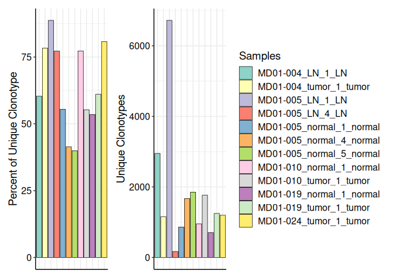

```r
p1 + p2 +
    plot_layout(guides = 'collect')
```

### Clonotype丰度

还可以按丰度检查克隆型的相对分布。这里 `abundanceContig()` 将生成一个折线图，其中克隆型总数按样本或运行中的实例数计算。与上面一样，我们还可以使用函数中的 group 变量按 contig 对象内的向量对其进行分组。

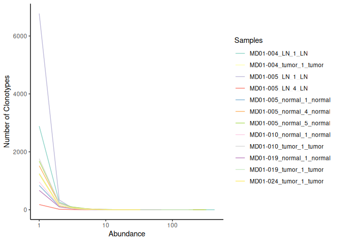

```r
abundanceContig(combined, cloneCall = "gene", scale = F)+
  scale_color_manual(values=my_color)
```

### Clonotype长度

可以通过调用 `lengtheContig()` 函数来查看CDR3序列的长度分布。重要的是，与其他基本可视化不同，cloneCall 只能是“nt”或“aa”。由于如上所述调用克隆型的方法，长度应显示多峰曲线，这是对未返回的链序列和单个条形码内的多个链使用 NA 的产物。

```r
p11 <- lengthContig(combined, cloneCall="aa", chain = "both") +
  scale_fill_manual(values=my_color) +
  theme_minimal() +    # 使用简单主题
  theme_bw() +
  theme(axis.title.x = element_blank(),
        axis.text.x = element_blank(),
        axis.text.y = element_text(size=12, color = "black"),
        axis.ticks.x = element_blank(),
        axis.title.y=element_text(size=14, color = "black"),
        legend.text=element_text(size=12),
        legend.title=element_text(size=14),
        panel.border = element_blank(),
        axis.line.y = element_line(color = "black"),
        axis.line.x = element_line(color = "black"),)
p22 <- lengthContig(combined, cloneCall="aa", chain = "TRB") +
  scale_fill_manual(values=my_color) +
  theme_minimal() +    # 使用简单主题
  theme_bw() +
  theme(axis.title.x = element_blank(),
        axis.text.x = element_blank(),
        axis.text.y = element_text(size=12, color = "black"),
        axis.ticks.x = element_blank(),
        axis.title.y=element_text(size=14, color = "black"),
        legend.text=element_text(size=12),
        legend.title=element_text(size=14),
        panel.border = element_blank(),
        axis.line.y = element_line(color = "black"),
        axis.line.x = element_line(color = "black"),)
```

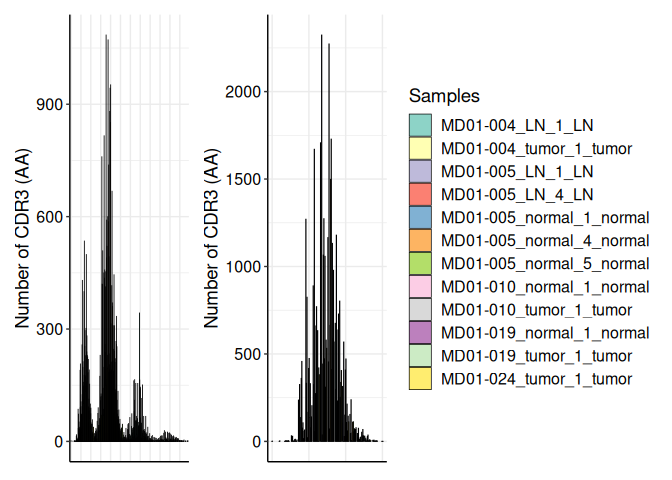

```r
p11 + p22 +
    plot_layout(guides = 'collect')
```

### Clonotypes 比较

可以使用 `compareClonotypes()` 函数查看样本之间的克隆型和动态变化。

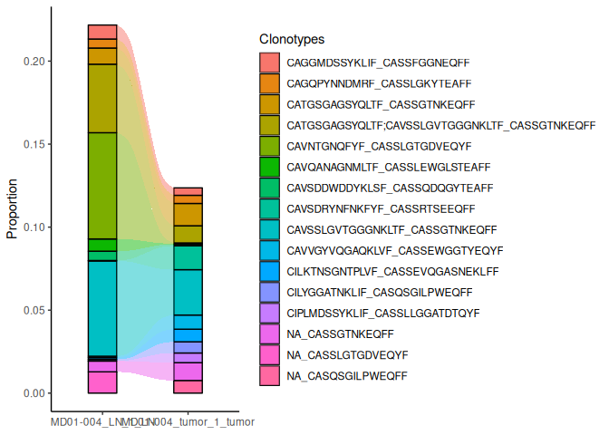

```r
compareClonotypes(combined,
                  numbers = 10,
                  samples = c("MD01-004_LN_1_LN", "MD01-004_tumor_1_tumor"),
                  cloneCall="aa",
                  graph = "alluvial")
```

### 可视化基因使用

最后一个基本分析可视化是 TCR 或 BCR 基因的相对使用情况，使用 `vizGenes()`

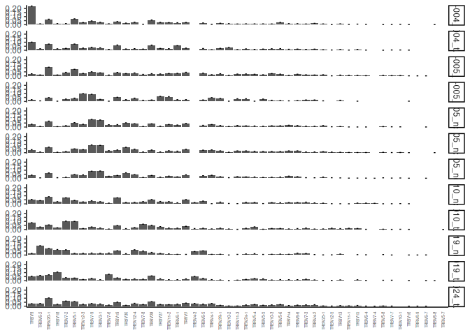

```r
vizGenes(combined, gene = "V",
         chain = "TRB",
         plot = "bar",
         order = "variance",
         scale = TRUE)
```

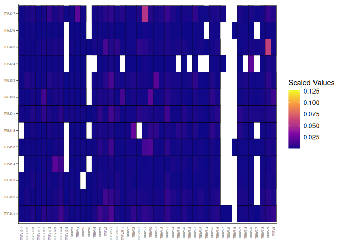

```r
vizGenes(combined[c(1,3,5)],
         gene = "V",
         chain = "TRB",
         y.axis = "J",
         plot = "heatmap",
         scale = TRUE,
         order = "gene")
```

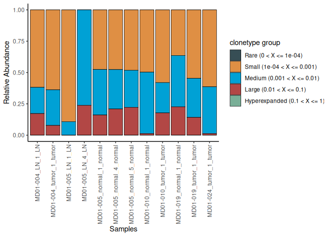

```r
clonalHomeostasis(combined, cloneCall = "gene",
                  cloneTypes = c(Rare = 1e-04,
                                 Small = 0.001,
                                 Medium = 0.01,
                                 Large = 0.1,
                                 Hyperexpanded = 1)) +
  theme(axis.text.x = element_text(angle=90, hjust=1, vjust=.5)) +
  #scale_shape_discrete(name="clonetype") #+
  scale_fill_jama(name="clonetype group")
```